# 2017-09-03-probability

### 시각화를 하면 다음과 같다.

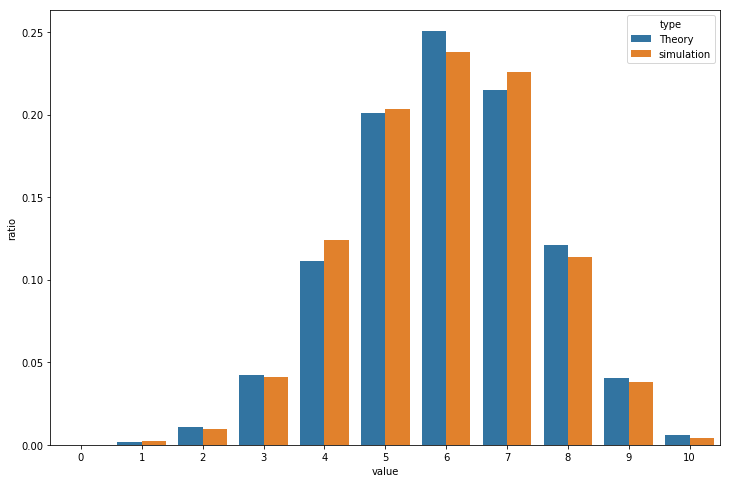

```python
plt.figure(figsize=(12,8))
sns.barplot(x="value", y="ratio", hue="type", data=df)
plt.show()
```

### scipy를 사용하여 시뮬레이션을 해보자.

```python
N = 10
p = 0.6
f = scipy.stats.binom(N, p)
x = np.arange(N + 1)
```

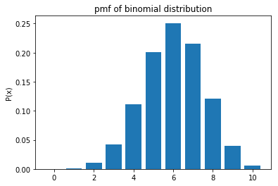

```python
plt.bar(x, f.pmf(x), align="center")
plt.ylabel("P(x)")
plt.title("pmf of binomial distribution")
plt.show()
```

```python
np.random.seed(0)
sample = f.rvs(100)
sample
```

```
array([ 6,  5,  6,  6,  6,  5,  6,  4,  3,  6,  5,  6,  6,  4,  8,  8,  9,
        5,  5,  4,  3,  5,  6,  5,  8,  5,  8,  4,  6,  6,  7,  5,  6,  6,
        9,  6,  6,  6,  4,  5,  7,  6,  5,  8,  5,  5,  7,  8,  7,  7,  6,
        6,  2,  8,  7,  8,  5,  7,  6,  7,  8,  8,  5,  8,  7,  7,  5,  8,
        4,  8,  3,  6,  3,  6,  5,  9,  7,  8,  7,  8,  7,  6,  8,  5,  6,
        7,  6,  8,  6,  4,  7,  5,  8,  5,  7,  7,  6,  9,  5, 10])
```

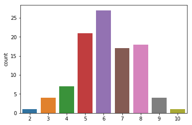

```python
sns.countplot(sample)
plt.show()
```

### scipy가 훨씬 편리하다는 것을 알 수 있다. scipy의 stats를 사용하자!

### Gaussian Normal Distribution 가우시안 정규 분포

- 연속형 확률 분포 함수

> 실수의 랜덤 변수 모형에서 가장 일반적으로 사용되는 확률 모형

> 평균 $\mu$와 분산 $\sigma^2$으로 정의

> 모든 확률 변수의 샘플평균은 가우시안 정규 분포로 수렴 (Central Limit Theorem)

> 동일한 표준편차를 가진 분포 중 최대 엔트로피를 가지는 확률 분포

> > 모든 자연 법칙에서 엔트로피는 커지는 경향이 있다. $$ X \sim N(x; \mu, \sigma^2) = \dfrac{1}{\sqrt{2\pi\sigma^2}} \exp \left(-\dfrac{(x-\mu)^2}{2\sigma^2}\right) $$

### 정규 분포의 시뮬레이션

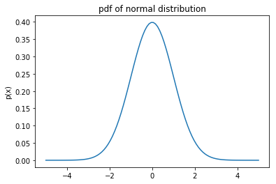

```python
# pdf(확률밀도함수) 정의
## 하이퍼 파라미터
mu = 0
std = 1

## pdf 생성
x = np.linspace(-5, 5, 100)
f = scipy.stats.norm(mu, std)

plt.plot(x, f.pdf(x))
plt.ylabel("p(x)")
plt.title("pdf of normal distribution")
plt.show()
```

```python
sample = f.rvs(1000)
sample;
```

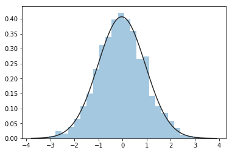

```python
sns.distplot(sample, kde=False, fit=scipy.stats.norm)
plt.show()
```

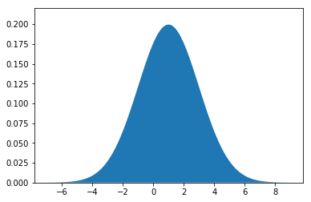

```python
mu_1 = 1
std_1 = 2
x_1 = np.linspace(-7, 9, 1000)
f_1 = scipy.stats.norm(mu_1, std_1)

# 면적을 칠해라.
plt.fill(x_1, f_1.pdf(x_1))
plt.ylim(0, 0.22);
```

### Q-Q Plot

> Quantile-Quantile Plot
> - 구체적인 정규 분포 검정(normality test)을 사용하기에 앞서 시작적으로 간단하게 정규 분포를 확인할 수 있는 방법
> - 동일 분위수에 해당하는 정상분포의 값과 주어진 분포의 값을 한 쌍으로 만들어 scatter plot을 그린다.
>   - 직선의 형태를 띌수록 정상 분포와 가깝다.

> Q-Q 플롯은 분석하고자 하는 샘플의 분포과 정규 분포의 분포 형태를 비교하는 시각적 도구

> > Q-Q 플롯은 동일 분위수에 해당하는 정상 분포의 값과 주어진 분포의 값을 한 쌍으로 만들어 스캐터 플롯(scatter plot)으로 그린 것
> > 1. 대상 샘플을 크기에 따라 정렬(sort)한다.
> > 2. 각 샘플의 분위수(quantile number)를 구한다.
> > 3. 각 샘플의 분위수와 일치하는 분위수를 가지는 정규 분포 값을 구한다.
> > 4. 대상 샘플과 정규 분포 값을 하나의 쌍으로 생각하여 2차원 공간에 하나의 점(point)으로 그린다.
> > 5. 모든 샘플에 대해 2부터 4까지의 과정을 반복하여 스캐터 플롯과 유사한 형태의 플롯을 완성한다.
> > 6. 비교를 위한 45도 직선을 그린다.

### Q-Q Plot을 그려보자.

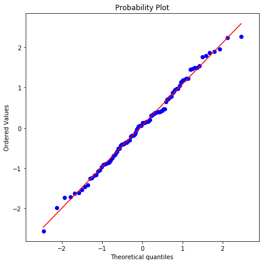

```python
# 정규분포에서 sampling(100)
np.random.seed(0)
x = np.random.randn(100)

plt.figure(figsize=(7,7))

## scipy에서 q-q plot을 그려주는 method
scipy.stats.probplot(x, plot=plt)

## x,y축의 간격 똑같게
plt.axis("equal")
plt.show()
```

#### 위는 시각적으로 정규분포를 따르는 것으로 판단된다.

- 이후 정규성 검정을 실시(Normality Test)

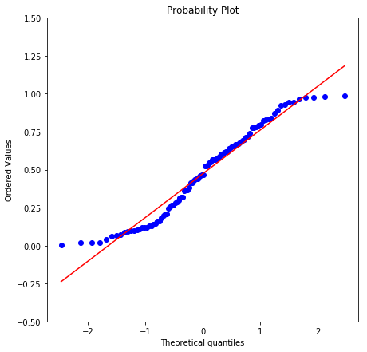

```python
np.random.seed(0)
# 위와 다른점은 정규분포에서 샘플링하지 않았다.
x = np.random.rand(100)

plt.figure(figsize=(7,7))
scipy.stats.probplot(x, plot=plt)
plt.ylim(-0.5, 1.5)
plt.show()
```

[output not shown]

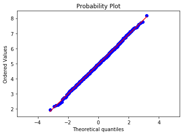

```python
x = scipy.stats.norm(5, 1).rvs(1000)
scipy.stats.probplot(x, plot=plt);
plt.axis("equal")
```

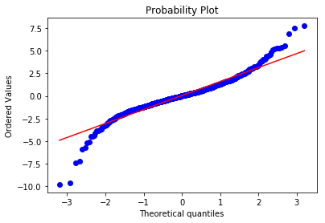

```python
x = scipy.stats.t(3).rvs(1000)
scipy.stats.probplot(x, plot=plt);
```

#### 위 처럼 시각적으로 판단하고, 정규성 검정을 하도록 하자.

### 중심 극한 정리(Central Limit Theorem)

> 중심 극한 정리는 어떤 분포를 따르는 확률 변수든 지 상관없이 표본의 수가 커지면 이 분포의 합은 정규 분포와 비슷한 분포를 이루는 현상을 말한다.

> 중심 극한 정리를 수학적인 용어로 쓰면 다음과 같다.

$$ X_1,\;X_2,\;\cdots, X_n의 \;기댓값과 \;\;분산이 \;\mu, \;\sigma^2으로 \;동일한 \;값을 \;갖으며, \;서로 \;독립인 \;확률 \;변수들이라고\; 하자.\; 분포가 \;어떤 \;분포인지는 \;상관없다. $$

이 분포의 합은 다음과 같다.

$$S_n\;=\;X_1+\cdots+X_n, \;\; 여기서 S_n도 \; 확률 \;변수이다.$$$$S_n의\; 분포는\; n이 \;증가할 \;수록 \;다음과\; 같은\; 정규\; 분포에\; 수렴한다.$$$$\frac{S_n - n\mu}{\sqrt{n}} \; \xrightarrow{d} \; N(0, \sigma^2)$$

### 중심극한 정리가 성립하는지 살펴보자.

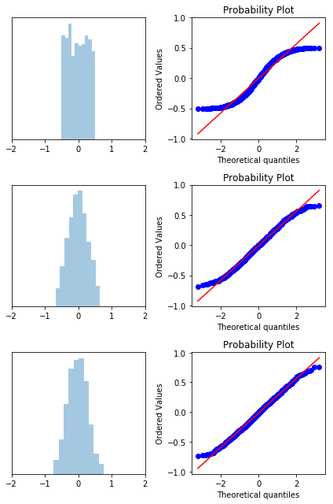

```python
x = np.linspace(-2, 2, 100)

plt.figure(figsize=(6,9))

# enumerate → 인덱스를 자동으로 넣어줌 / 아래는 (0,1), (1,2), (2,10)의 for 문이 돌아간다.
for i, N in enumerate([1, 2, 10]):
    X = np.random.rand(1000, N) - 0.5
    S = X.sum(axis=1)/np.sqrt(N)
    plt.subplot(3, 2, 2*i+1)
    sns.distplot(S, bins=10, kde=False, norm_hist=True)
    plt.xlim(-2, 2)
    plt.yticks([])
    plt.subplot(3, 2, 2*i+2)
    scipy.stats.probplot(S, plot=plt)

plt.tight_layout()
plt.show()
```